# Modeling Mortgage Applications: EDA/Cleaning (Capstone Part 1/2)

Kevin Wang

*Note: eval set to False in some segments as modeling was done using a script, so results were already obtained prior. Pictures of relevant outputs are included instead. Re-computation would take an excessive amount of time. Set eval to true to run from scratch.*

## Introduction

The Consumer Financial Protection Bureau (CFPB) is a U.S. government agency responsible for protecting consumers from unfair treatment by financial institutions (banks, lenders, etc.)

The Home Mortgage Disclosure Act (HMDA) requires many institutions to publicly disclose mortgage data to the public. Data is available on their website at https://www.consumerfinance.gov/data-research/hmda/historic-data/

## Data Acquisition

Data from 2007-2017 available for download on the website. It is available in both encoded and plain language forms. To save memory and processing power, use only the encoded data and consult the code explanation sheet to interpret the results.

Download and analyze the 2017 data for now. If another year is desired, then simply change the file to be loaded.

```r
data_all <- fread("hmda_2017_nationwide_all-records_codes.csv")
```

```r
colnames(data_all)
```

```
##  [1] "as_of_year"                     "respondent_id"
##  [3] "agency_code"                    "loan_type"
##  [5] "property_type"                  "loan_purpose"
##  [7] "owner_occupancy"                "loan_amount_000s"
##  [9] "preapproval"                    "action_taken"
## [11] "msamd"                          "state_code"
## [13] "county_code"                    "census_tract_number"
## [15] "applicant_ethnicity"            "co_applicant_ethnicity"
## [17] "applicant_race_1"               "applicant_race_2"
## [19] "applicant_race_3"               "applicant_race_4"
## [21] "applicant_race_5"               "co_applicant_race_1"
## [23] "co_applicant_race_2"            "co_applicant_race_3"
## [25] "co_applicant_race_4"            "co_applicant_race_5"
## [27] "applicant_sex"                  "co_applicant_sex"
## [29] "applicant_income_000s"          "purchaser_type"
## [31] "denial_reason_1"                "denial_reason_2"
## [33] "denial_reason_3"                "rate_spread"
## [35] "hoepa_status"                   "lien_status"
## [37] "edit_status"                    "sequence_number"
## [39] "population"                     "minority_population"
## [41] "hud_median_family_income"       "tract_to_msamd_income"
## [43] "number_of_owner_occupied_units" "number_of_1_to_4_family_units"
## [45] "application_date_indicator"
```

```r
str(data_all)
```

```
## Classes 'data.table' and 'data.frame':   14285496 obs. of  45 variables:
##  $ as_of_year                    : int  2017 2017 2017 2017 2017 2017 2017 2017 2017 2017 ...
##  $ respondent_id                 : chr  "0000342634" "0004186591" "22-3039688" "20-3878295" ...
##  $ agency_code                   : int  9 9 7 5 9 7 3 9 7 7 ...
##  $ loan_type                     : int  1 3 3 1 1 3 2 1 3 1 ...
##  $ property_type                 : int  1 1 1 1 1 1 1 1 1 1 ...
##  $ loan_purpose                  : int  3 1 3 2 3 3 1 3 3 3 ...
##  $ owner_occupancy               : int  1 1 1 1 2 1 1 1 1 1 ...
##  $ loan_amount_000s              : int  9 94 161 90 41 146 76 175 186 106 ...
##  $ preapproval                   : int  3 3 3 3 3 3 3 3 3 3 ...
##  $ action_taken                  : int  3 6 5 1 1 6 1 4 1 1 ...
##  $ msamd                         : int  33860 33860 33860 33860 33860 33860 33860 33860 33860 33860 ...
##  $ state_code                    : int  1 1 1 1 1 1 1 1 1 1 ...
##  $ county_code                   : int  1 1 1 1 1 1 1 1 1 1 ...
##  $ census_tract_number           : num  201 201 201 201 201 201 201 201 201 201 ...
```

[output cut: 32 more lines]

```r
summary(data_all)
```

```
##    as_of_year   respondent_id       agency_code      loan_type
##  Min.   :2017   Length:14285496    Min.   :1.000   Min.   :1.00
##  1st Qu.:2017   Class :character   1st Qu.:7.000   1st Qu.:1.00
##  Median :2017   Mode  :character   Median :7.000   Median :1.00
##  Mean   :2017                      Mean   :6.809   Mean   :1.44
##  3rd Qu.:2017                      3rd Qu.:9.000   3rd Qu.:2.00
##  Max.   :2017                      Max.   :9.000   Max.   :4.00
##
##  property_type    loan_purpose   owner_occupancy loan_amount_000s
##  Min.   :1.000   Min.   :1.000   Min.   :1.000   Min.   :      1
##  1st Qu.:1.000   1st Qu.:1.000   1st Qu.:1.000   1st Qu.:    112
##  Median :1.000   Median :1.000   Median :1.000   Median :    185
##  Mean   :1.044   Mean   :1.845   Mean   :1.102   Mean   :    248
##  3rd Qu.:1.000   3rd Qu.:3.000   3rd Qu.:1.000   3rd Qu.:    290
##  Max.   :3.000   Max.   :3.000   Max.   :3.000   Max.   :3400000
##                                                  NA's   :5036
##   preapproval     action_taken       msamd           state_code
##  Min.   :1.000   Min.   :1.000   Min.   :10140     Min.   : 1.00
##  1st Qu.:3.000   1st Qu.:1.000   1st Qu.:19660     1st Qu.:12.00
##  Median :3.000   Median :1.000   Median :32780     Median :26.00
##  Mean   :2.796   Mean   :2.627   Mean   :30458     Mean   :27.06
##  3rd Qu.:3.000   3rd Qu.:4.000   3rd Qu.:40140     3rd Qu.:42.00
##  Max.   :3.000   Max.   :8.000   Max.   :49780     Max.   :78.00
##                                  NA's   :1791050   NA's   :197158
##   county_code     census_tract_number applicant_ethnicity
##  Min.   :  1.00   Min.   :    1.0     Min.   :1.000
##  1st Qu.: 29.00   1st Qu.:  103.4     1st Qu.:2.000
##  Median : 63.00   Median :  406.0     Median :2.000
##  Mean   : 85.52   Mean   : 2215.6     Mean   :2.227
##  3rd Qu.:109.00   3rd Qu.: 3502.0     3rd Qu.:2.000
##  Max.   :840.00   Max.   :10000.0     Max.   :4.000
##  NA's   :245597   NA's   :284302
##  co_applicant_ethnicity applicant_race_1 applicant_race_2   applicant_race_3
##  Min.   :1.000          Min.   :1.000    Min.   :1          Min.   :1
##  1st Qu.:2.000          1st Qu.:5.000    1st Qu.:4          1st Qu.:3
##  Median :5.000          Median :5.000    Median :5          Median :5
##  Mean   :3.759          Mean   :5.006    Mean   :4          Mean   :4
##  3rd Qu.:5.000          3rd Qu.:5.000    3rd Qu.:5          3rd Qu.:5
##  Max.   :5.000          Max.   :7.000    Max.   :5          Max.   :5
##                                          NA's   :14195114   NA's   :14278506
```

[output cut: 49 more lines]

```
##  Min.   :    0                  Min.   :    0
##  1st Qu.:  926                  1st Qu.: 1341
##  Median : 1321                  Median : 1817
##  Mean   : 1465                  Mean   : 2004
##  3rd Qu.: 1808                  3rd Qu.: 2422
##  Max.   :19529                  Max.   :25391
##  NA's   :284352                 NA's   :284352
##  application_date_indicator
##  Mode:logical
##  NA's:14285496
##
##
##
##
##
```

## Data Cleaning

Lots of features to manage. Discard features where they were all NA (edit_status, sequence_number, application_date_indicator), all the same (as_of_year), and ID (respondent_id).

```r
hmda <- subset(data_all,select=-c(as_of_year,respondent_id,edit_status,
                                  sequence_number,application_date_indicator))
rm(data_all)
```

Not all applications featured a co-applicant. In addition, a large majority of people only listed 1 race.

```r
# 8 = no co-applicant
table(hmda$co_applicant_race_1)
```

```
##
##       1       2       3       4       5       6       7       8
##   37661  314750  247658   36315 4153379  768723 1261891 7465119
```

```r
# View % of (co)applicants who are multiracial
sum(table(hmda$co_applicant_race_2))/nrow(hmda)
```

```
## [1] 0.002129013
```

```r
sum(table(hmda$applicant_race_2))/nrow(hmda)
```

```
## [1] 0.006326837
```

Create new Boolean features for whether applicant was multiracial and whether application had a co-applicant. Also, take Action Taken as the feature to extract the future dependent variable from. Action taken is encoded as follows:

| Code | Meaning |
| --- | --- |
| 1 | Loan Originated |
| 2 | Application approved but not accepted |
| 3 | Application denied by financial institution |
| 4 | Application withdrawn by applicant |
| 5 | File closed for incompleteness |
| 6 | Loan purchased by institution |
| 7 | Preapproval request denied |
| 8 | Preapproval request approved but not accepted |

Group actions 1,2, and 8 as “Approved” (1), else “Not approved” (0), creating a new binary feature.

```r
hmda$multirace <- ifelse(!is.na(hmda$applicant_race_2),yes=1,no=0)
hmda$coapplicant <- ifelse(hmda$co_applicant_race_1==8,yes=0,no=1)
hmda$approved <- ifelse((hmda$action_taken %in% c(1,2,8) ),yes=1,no=0)
```

Since a lot of the features are actually encoded factors, set said features as factors:

```r
factorcols <- colnames(hmda)
factorcols <- factorcols[!factorcols %in% c("loan_amount_000s","applicant_income_000s","population",
                                            "minority_population","hud_median_family_income",
                                            "tract_to_msamd_income","number_of_owner_occupied_units",
                                            "number_of_1_to_4_family_units","rate_spread")]
hmda[,(factorcols):= lapply(.SD, as.factor), .SDcols = factorcols]

str(hmda)
```

```
## Classes 'data.table' and 'data.frame':   14285496 obs. of  43 variables:
##  $ agency_code                   : Factor w/ 6 levels "1","2","3","5",..: 6 6 5 4 6 5 3 6 5 5 ...
##  $ loan_type                     : Factor w/ 4 levels "1","2","3","4": 1 3 3 1 1 3 2 1 3 1 ...
##  $ property_type                 : Factor w/ 3 levels "1","2","3": 1 1 1 1 1 1 1 1 1 1 ...
##  $ loan_purpose                  : Factor w/ 3 levels "1","2","3": 3 1 3 2 3 3 1 3 3 3 ...
##  $ owner_occupancy               : Factor w/ 3 levels "1","2","3": 1 1 1 1 2 1 1 1 1 1 ...
##  $ loan_amount_000s              : int  9 94 161 90 41 146 76 175 186 106 ...
##  $ preapproval                   : Factor w/ 3 levels "1","2","3": 3 3 3 3 3 3 3 3 3 3 ...
##  $ action_taken                  : Factor w/ 8 levels "1","2","3","4",..: 3 6 5 1 1 6 1 4 1 1 ...
##  $ msamd                         : Factor w/ 748 levels "10140","10180",..: 446 446 446 446 446 446 446 446 446 446 ...
##  $ state_code                    : Factor w/ 53 levels "1","2","4","5",..: 1 1 1 1 1 1 1 1 1 1 ...
##  $ county_code                   : Factor w/ 327 levels "1","3","5","6",..: 1 1 1 1 1 1 1 1 1 1 ...
##  $ census_tract_number           : Factor w/ 23832 levels "1","1.01","1.02",..: 4270 4270 4270 4270 4270 4270 4270 4270 4270 4270 ...
##  $ applicant_ethnicity           : Factor w/ 4 levels "1","2","3","4": 2 4 2 2 2 2 2 2 2 2 ...
##  $ co_applicant_ethnicity        : Factor w/ 5 levels "1","2","3","4",..: 5 4 1 2 2 5 5 5 5 5 ...
```

[output cut: 30 more lines]

```r
summary(hmda)
```

```
##  agency_code loan_type   property_type loan_purpose owner_occupancy
##  1: 463411   1:9950346   1:13706551    1:7703630    1:12887163
##  2: 366432   2:2659118   2:  527095    2:1091772    2: 1335445
##  3:1128554   3:1402700   3:   51850    3:5490094    3:   62888
##  5:1020531   4: 273332
##  7:7083670
##  9:4222898
##
##  loan_amount_000s  preapproval   action_taken         msamd
##  Min.   :      1   1:  481384   1      :7339057   31084  :  350698
##  1st Qu.:    112   2: 1944405   6      :2086676   12060  :  324251
##  Median :    185   3:11859707   3      :2009743   35614  :  317529
##  Mean   :    248                4      :1696289   38060  :  310974
##  3rd Qu.:    290                5      : 601148   16974  :  307806
##  Max.   :3400000                2      : 409797   (Other):10883188
##  NA's   :5036                   (Other): 142786   NA's   : 1791050
##    state_code       county_code       census_tract_number applicant_ethnicity
##  6      :1714459   13     :  502321   2      :   44842    1:1343306
##  48     :1148206   37     :  481896   9501   :   43588    2:9877958
##  12     :1018763   3      :  453027   3      :   41640    3:1543770
##  17     : 502511   31     :  451955   1      :   41099    4:1520462
##  13     : 501310   1      :  347985   9502   :   41085
##  (Other):9203089   (Other):11802715   (Other):13788940
##  NA's   : 197158   NA's   :  245597   NA's   :  284302
##  co_applicant_ethnicity applicant_race_1 applicant_race_2 applicant_race_3
##  1: 535340              1: 109588        1   :    2966    1   :     256
##  2:4282121              2: 692059        2   :    4681    2   :     122
##  3: 738020              3:1002556        3   :   10771    3   :    1464
##  4:1264895              4:  59027        4   :    7090    4   :     586
##  5:7465120              5:9267426        5   :   64874    5   :    4562
##                         6:1641022        NA's:14195114    NA's:14278506
##                         7:1513818
##  applicant_race_4 applicant_race_5 co_applicant_race_1 co_applicant_race_2
##  1   :      26    1   :      46    8      :7465119     1   :     852
##  2   :      61    2   :      16    5      :4153379     2   :    1873
##  3   :      22    3   :      13    7      :1261891     3   :    2440
##  4   :    1033    4   :      10    6      : 768723     4   :    2958
##  5   :     502    5   :     999    2      : 314750     5   :   22291
##  NA's:14283852    NA's:14284412    3      : 247658     NA's:14255082
##                                    (Other):  73976
```

[output cut: 33 more lines]

```
##  Min.   :  0.00        Min.   :    0
##  1st Qu.: 86.49        1st Qu.:  926
##  Median :107.70        Median : 1321
##  Mean   :113.02        Mean   : 1465
##  3rd Qu.:133.13        3rd Qu.: 1808
##  Max.   :507.47        Max.   :19529
##  NA's   :284308        NA's   :284352
##  number_of_1_to_4_family_units multirace    coapplicant approved
##  Min.   :    0                 0:14195114   0:7465119   0:6500536
##  1st Qu.: 1341                 1:   90382   1:6820377   1:7784960
##  Median : 1817
##  Mean   : 2004
##  3rd Qu.: 2422
##  Max.   :25391
##  NA's   :284352
```

## EDA

Proceed with some EDA:

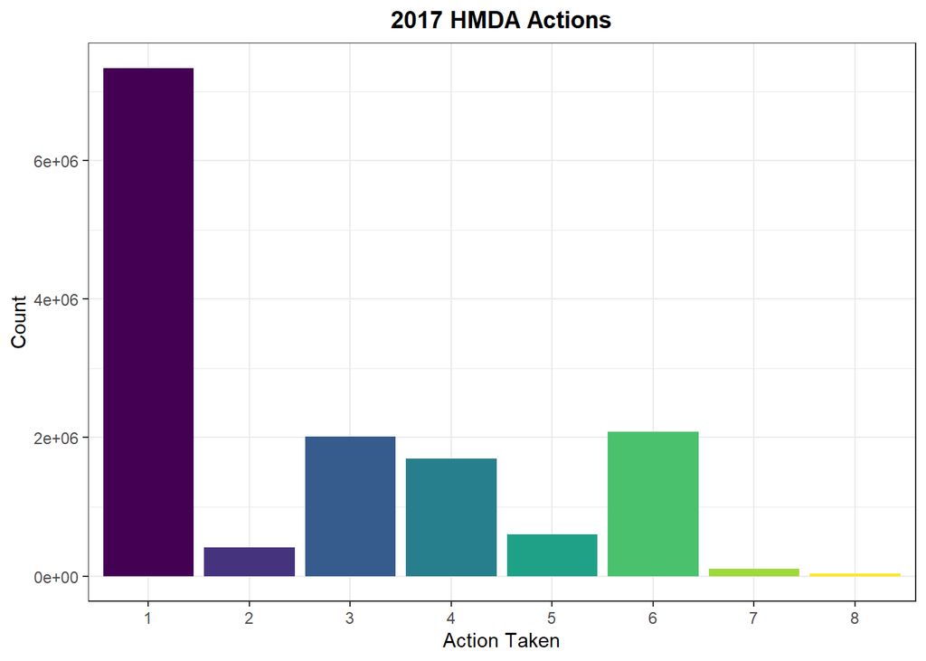

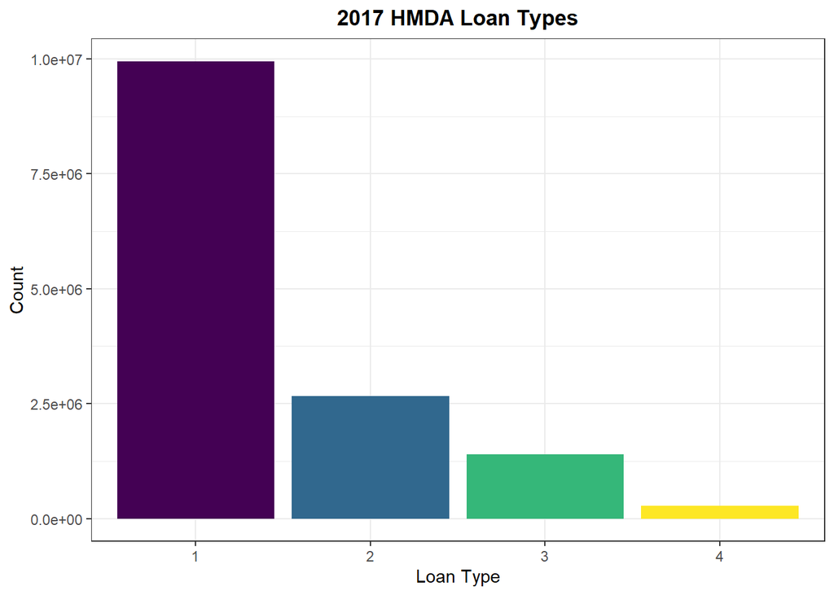

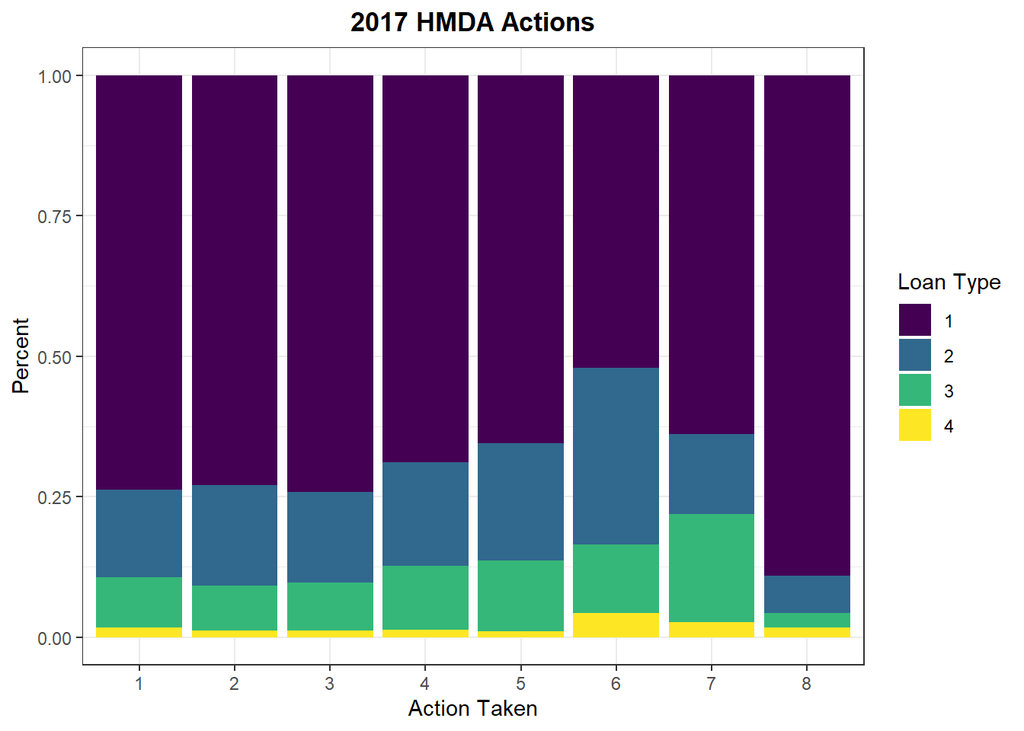

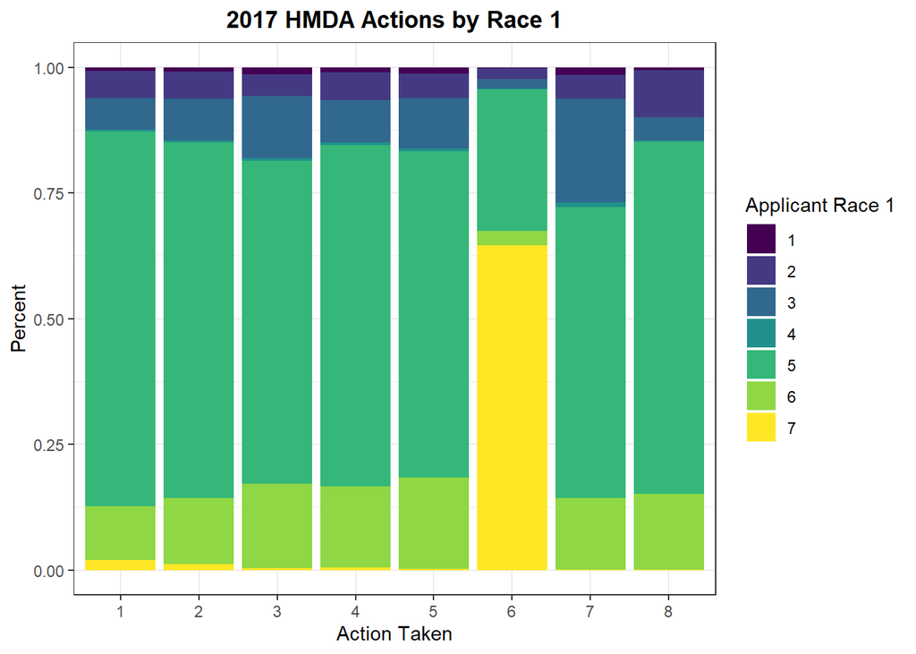

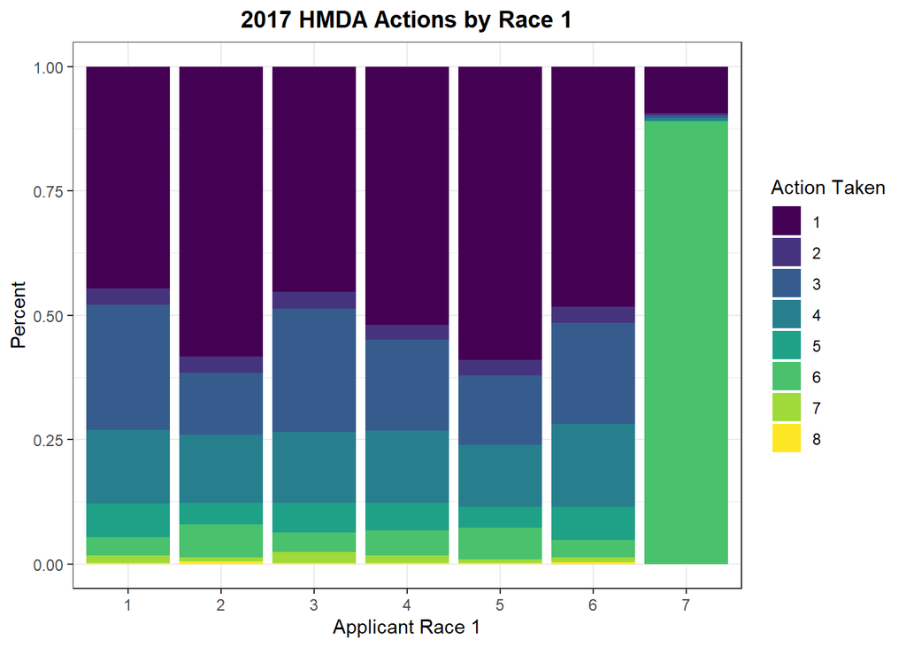

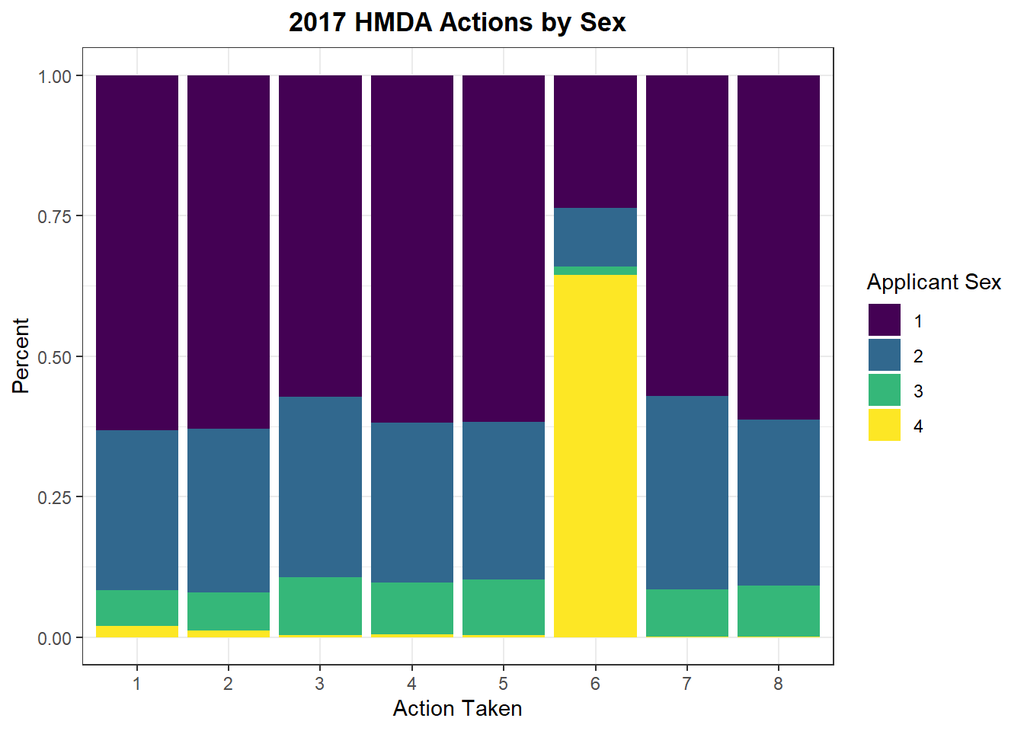

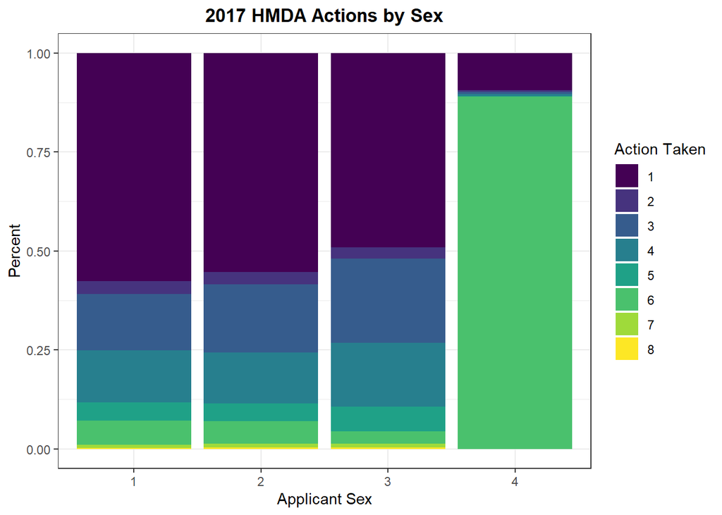

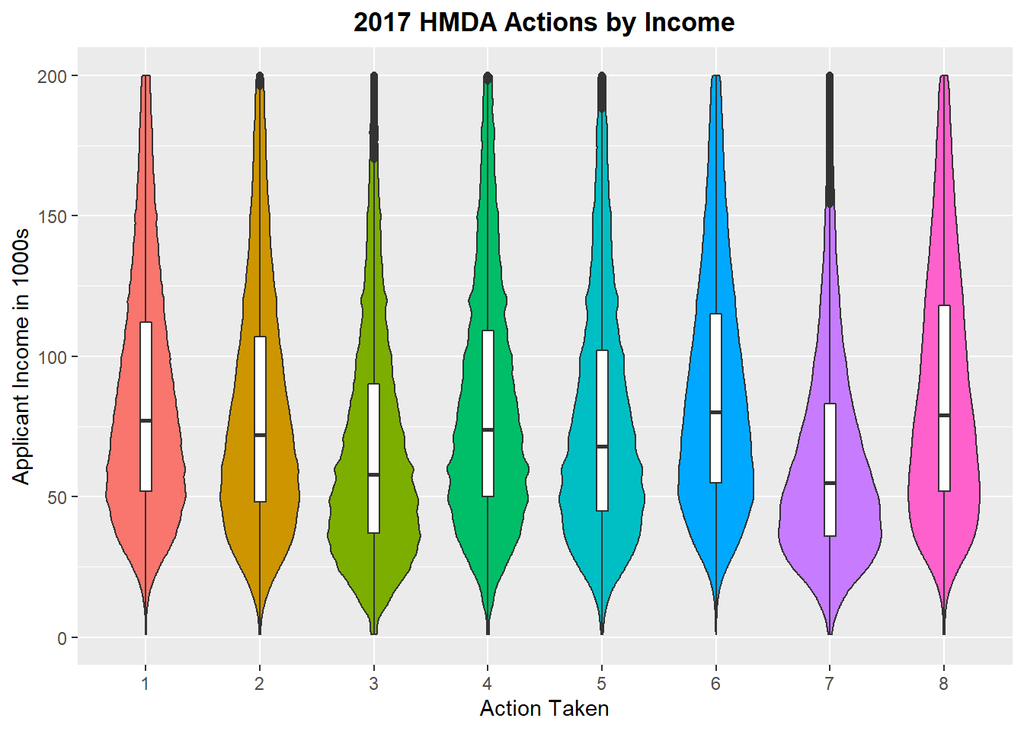

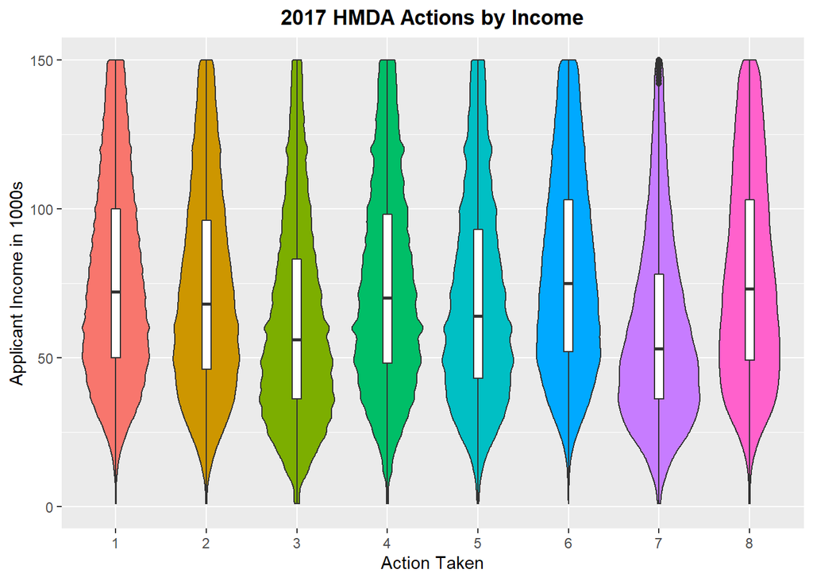

It does appear that different values within some features affect the approval rates.

Action 6 seems out of place. It represents transactions involving a loan being sold from one institution to another, not new mortgage applications. So removing them is prudent.

```r
hmda_reduced <-subset(hmda,select=-c(applicant_race_2,applicant_race_3,applicant_race_4,
                             applicant_race_5,co_applicant_race_2,co_applicant_race_3,
                             co_applicant_race_4,co_applicant_race_5))

hmda_reduced <- subset(hmda_reduced, action_taken != 6)
summary(hmda_reduced)
```

```
##  agency_code loan_type   property_type loan_purpose owner_occupancy
##  1: 442410   1:8864476   1:11647271    1:6183423    1:10930405
##  2: 363025   2:2001048   2:  503512    2:1058084    2: 1218444
##  3:1090112   3:1150399   3:   48037    3:4957313    3:   49971
##  5:1004198   4: 182897
##  7:6422226
##  9:2876849
##
##  loan_amount_000s  preapproval  action_taken         msamd
##  Min.   :      1   1: 481384   1      :7339057   31084  : 301863
##  1st Qu.:    106   2:1944405   3      :2009743   12060  : 273380
##  Median :    181   3:9773031   4      :1696289   35614  : 272714
##  Mean   :    250               5      : 601148   38060  : 253183
##  3rd Qu.:    288               2      : 409797   16974  : 251282
##  Max.   :3400000               7      : 106680   (Other):9236061
##  NA's   :5036                  (Other):  36106   NA's   :1610337
##    state_code       county_code       census_tract_number applicant_ethnicity
##  6      :1481012   13     :  420177   9501   :   39185    1:1274257
##  48     : 952255   37     :  412343   2      :   38971    2:9266187
##  12     : 872563   3      :  381580   9502   :   36701    3:1486668
##  13     : 424412   31     :  376802   3      :   36144    4: 171708
##  17     : 418055   1      :  300074   1      :   35818
##  (Other):7855452   (Other):10064559   (Other):11730142
##  NA's   : 195071   NA's   :  243285   NA's   :  281859
##  co_applicant_ethnicity applicant_race_1 co_applicant_race_1 applicant_sex
##  1: 506010              1: 105610        8      :6971941     1:7553572
##  2:3998294              2: 645602        5      :3875449     2:3544424
##  3: 708435              3: 963483        6      : 737931     3: 934319
##  4:  14139              4:  56077        2      : 293440     4: 166505
##  5:6971942              5:8679427        3      : 237232
##                         6:1582211        1      :  36261
##                         7: 166410        (Other):  46566
##  co_applicant_sex applicant_income_000s purchaser_type    denial_reason_1
##  1:1076928        Min.   :      1       0      :6860968   3      :  392096
##  2:3688039        1st Qu.:     50       1      :1381310   1      :  384777
##  3: 450008        Median :     78       2      : 971881   4      :  220014
##  4:  11902        Mean   :    115       3      : 907204   7      :  179330
##  5:6971943        3rd Qu.:    122       7      : 819896   9      :  126294
##                   Max.   :7073045       6      : 733572   (Other):  109459
##                   NA's   :758600        (Other): 523989   NA's   :10786850
```

[output cut: 17 more lines]

```
##  Min.   :  0.00        Min.   :    0
##  1st Qu.: 86.46        1st Qu.:  923
##  Median :107.60        Median : 1317
##  Mean   :113.05        Mean   : 1459
##  3rd Qu.:133.04        3rd Qu.: 1802
##  Max.   :507.47        Max.   :19529
##  NA's   :281865        NA's   :281907
##  number_of_1_to_4_family_units multirace    coapplicant approved
##  Min.   :    0                 0:12112119   0:6971941   0:4413860
##  1st Qu.: 1340                 1:   86701   1:5226879   1:7784960
##  Median : 1816
##  Mean   : 2000
##  3rd Qu.: 2417
##  Max.   :25391
##  NA's   :281907
```

```r
rm(hmda)
```

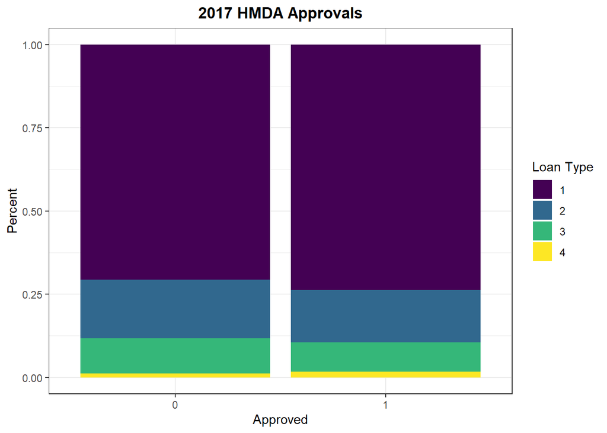

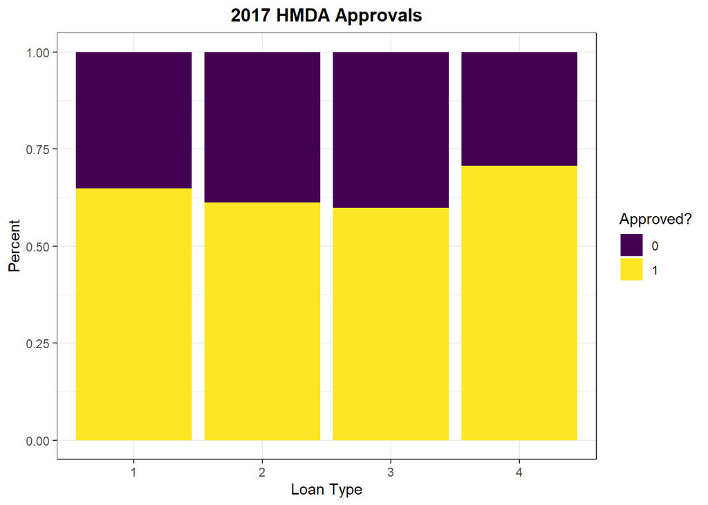

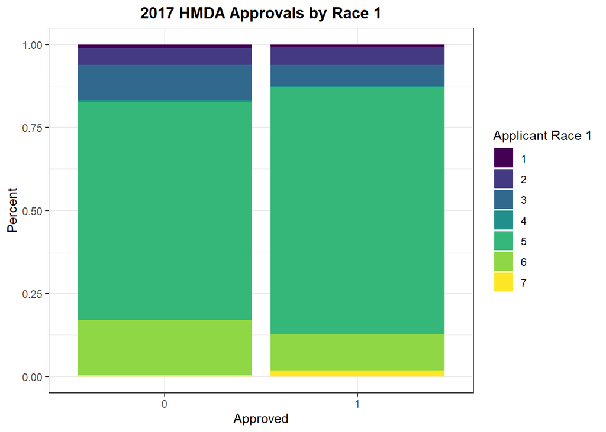

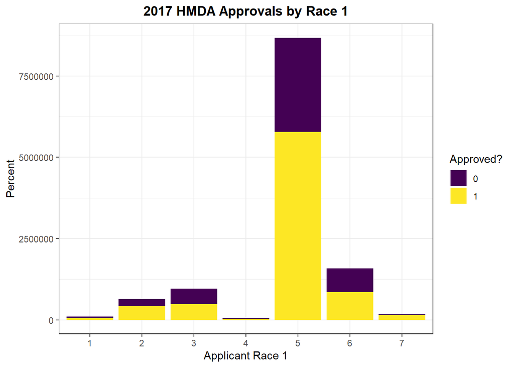

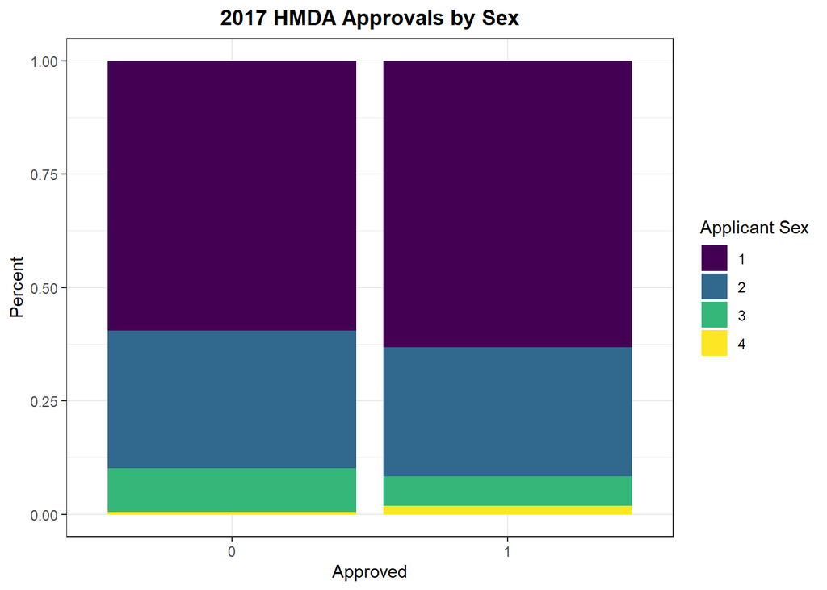

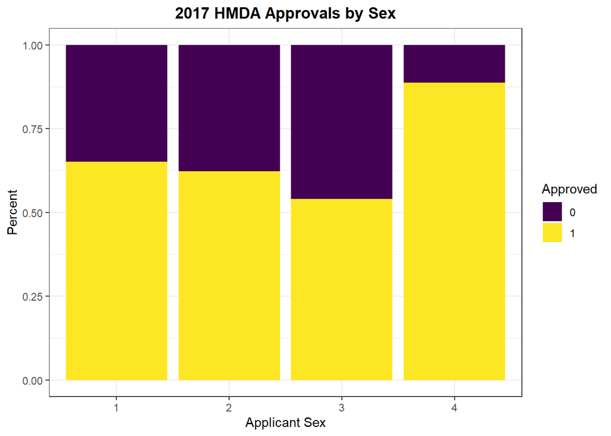

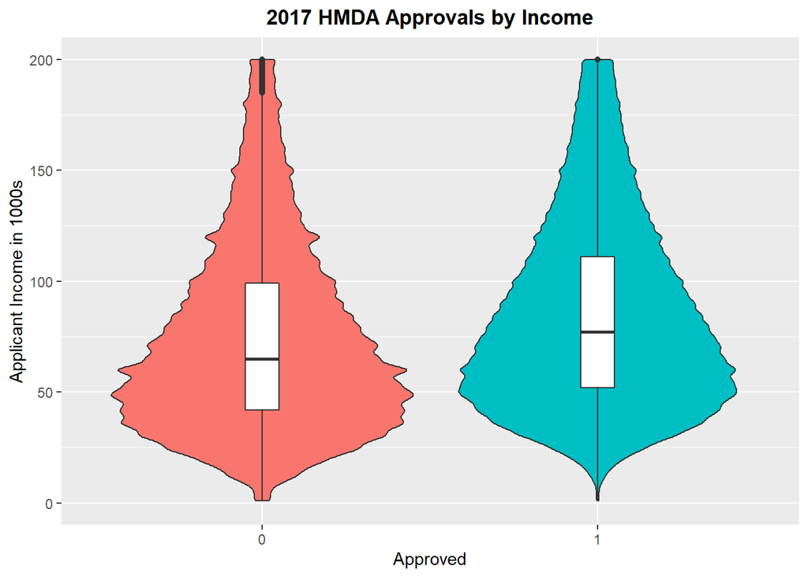

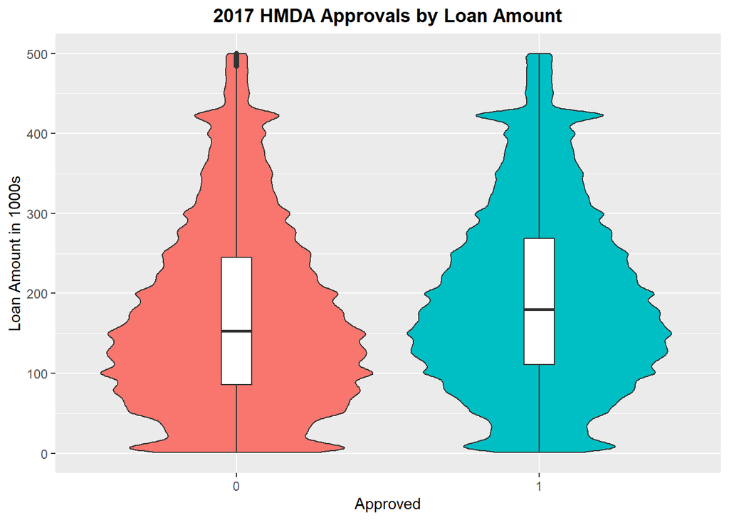

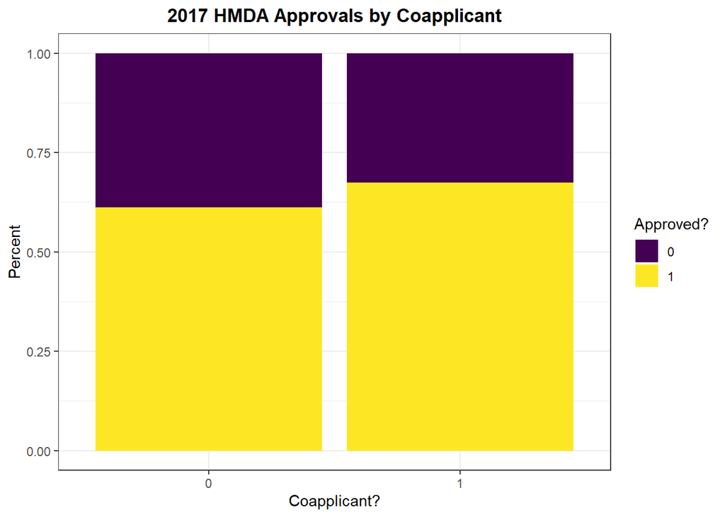

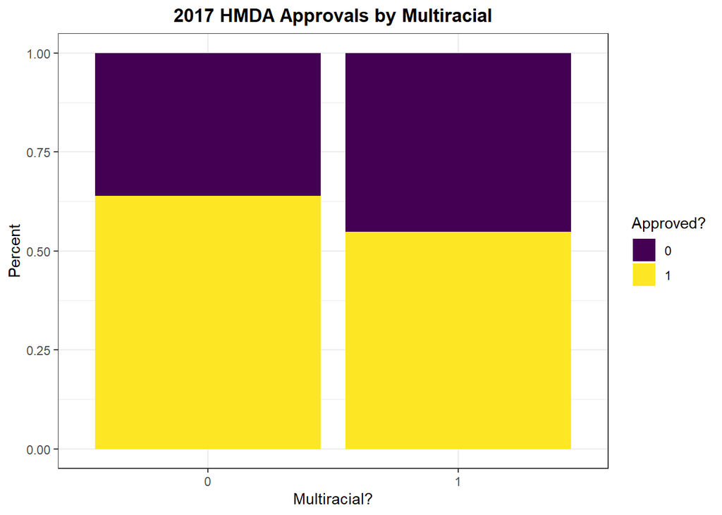

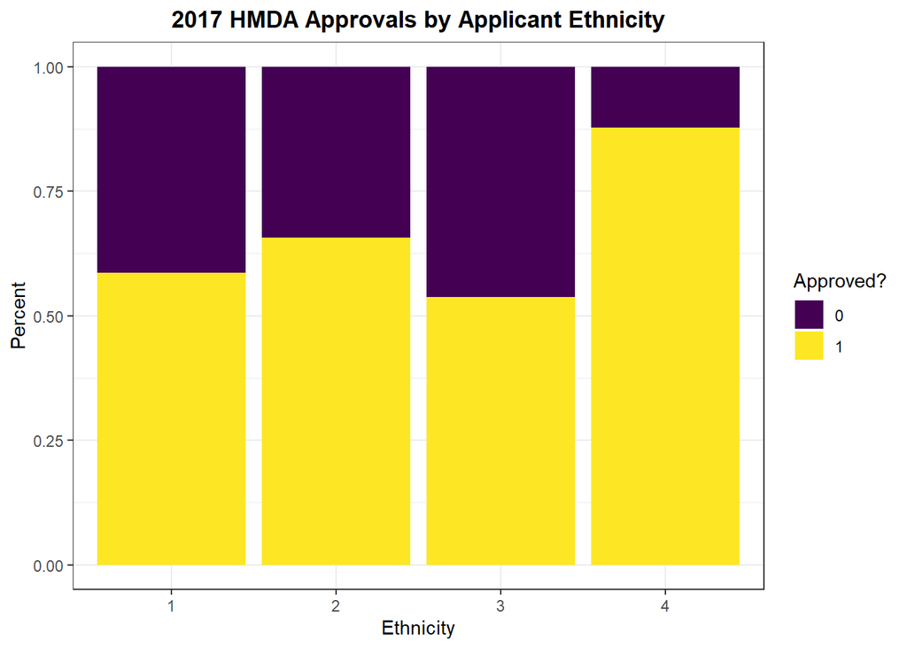

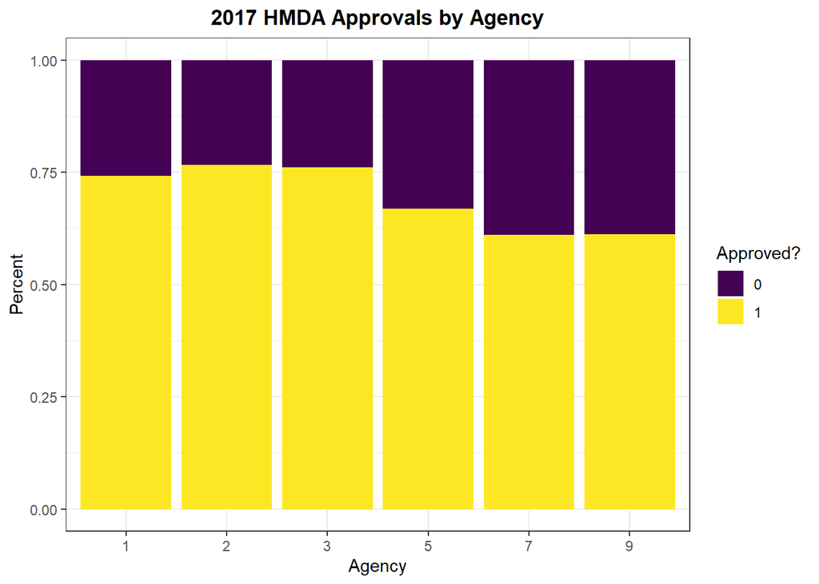

[2 more figures not shown]

Upon further inspection, action 4 could also be removed, as they represent instances where the applicant(s) took themselves out of consideration.

```r
hmda_reduced <- subset(hmda_reduced, action_taken != 4)
summary(hmda_reduced)
```

```
##  agency_code loan_type   property_type loan_purpose owner_occupancy
##  1: 399528   1:7695975   1:9990781     1:5457050    1:9402501
##  2: 322747   2:1688464   2: 467646     2: 966613    2:1054469
##  3: 984694   3: 956251   3:  44104     3:4078868    3:  45561
##  5: 892756   4: 161841
##  7:5352576
##  9:2550230
##
##  loan_amount_000s  preapproval  action_taken         msamd
##  Min.   :      1   1: 441354   1      :7339057   31084  : 252391
##  1st Qu.:    104   2:1685179   3      :2009743   35614  : 231514
##  Median :    180   3:8375998   5      : 601148   12060  : 229811
##  Mean   :    247               2      : 409797   16974  : 214948
##  3rd Qu.:    286               7      : 106680   38060  : 210446
##  Max.   :3400000               8      :  36106   (Other):7937644
##  NA's   :2913                  (Other):      0   NA's   :1425777
##    state_code       county_code      census_tract_number applicant_ethnicity
##  6      :1239643   13     : 353874   9501   :   34806    1:1088166
##  48     : 811318   37     : 347910   2      :   33955    2:8011794
##  12     : 736170   3      : 327796   9502   :   32729    3:1241064
##  17     : 363001   31     : 320511   3      :   31392    4: 161507
##  13     : 360539   1      : 256913   1      :   31165
##  (Other):6807691   (Other):8676775   (Other):10084879
##  NA's   : 184169   NA's   : 218752   NA's   :  253605
##  co_applicant_ethnicity applicant_race_1 co_applicant_race_1 applicant_sex
##  1: 432868              1:  89350        8      :5975653     1:6504692
##  2:3482016              2: 550846        5      :3383507     2:3061118
##  3: 599437              3: 821148        6      : 619293     3: 779027
##  4:  12556              4:  47530        2      : 251022     4: 157694
##  5:5975654              5:7526154        3      : 202763
##                         6:1309894        1      :  30700
##                         7: 157609        (Other):  39593
##  co_applicant_sex applicant_income_000s purchaser_type    denial_reason_1
##  1: 938242        Min.   :     1.0      0      :5164679   3      : 392096
##  2:3199256        1st Qu.:    50.0      1      :1381310   1      : 384777
##  3: 378504        Median :    78.0      2      : 971881   4      : 220014
##  4:  10874        Mean   :   112.9      3      : 907204   7      : 179330
##  5:5975655        3rd Qu.:   122.0      7      : 819896   9      : 126294
##                   Max.   :610715.0      6      : 733572   (Other): 109459
##                   NA's   :638149        (Other): 523989   NA's   :9090561
```

[output cut: 17 more lines]

```
##  Min.   :  0.00        Min.   :    0
##  1st Qu.: 86.53        1st Qu.:  926
##  Median :107.57        Median : 1319
##  Mean   :113.03        Mean   : 1461
##  3rd Qu.:132.91        3rd Qu.: 1803
##  Max.   :507.47        Max.   :19529
##  NA's   :253607        NA's   :253629
##  number_of_1_to_4_family_units multirace    coapplicant approved
##  Min.   :    0                 0:10430042   0:5975653   0:2717571
##  1st Qu.: 1343                 1:   72489   1:4526878   1:7784960
##  Median : 1818
##  Mean   : 2001
##  3rd Qu.: 2419
##  Max.   :25391
##  NA's   :253629
```

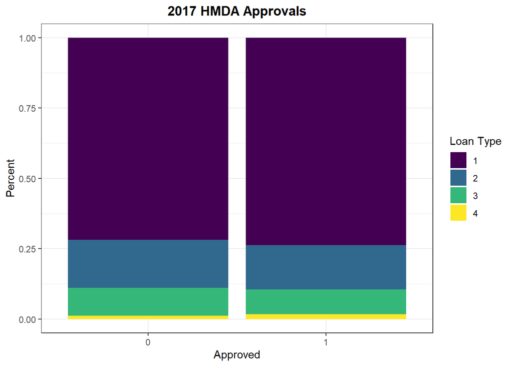

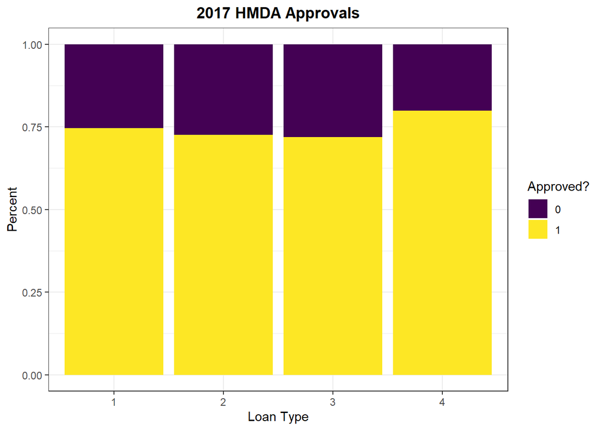

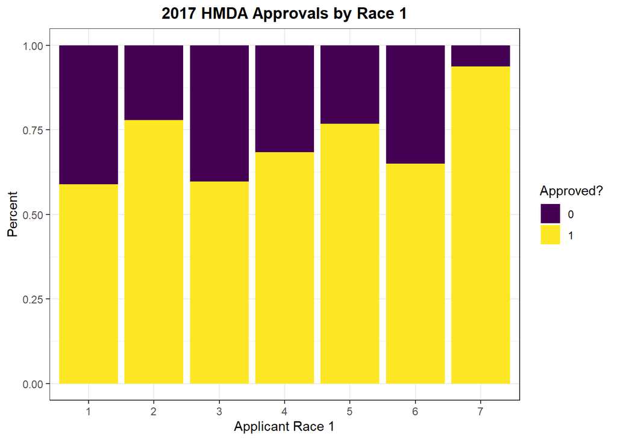

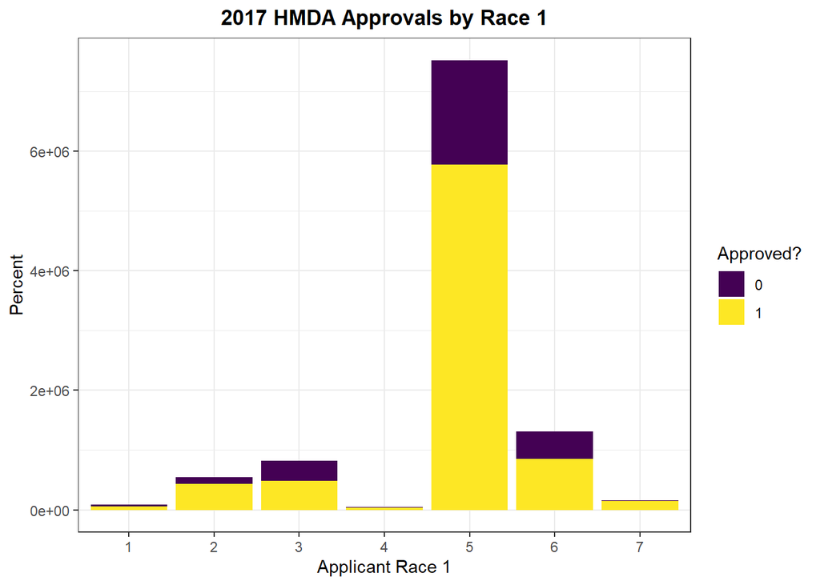

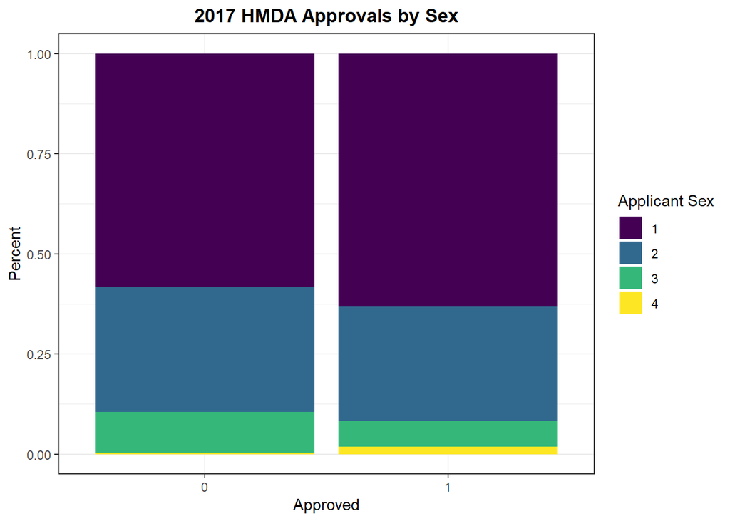

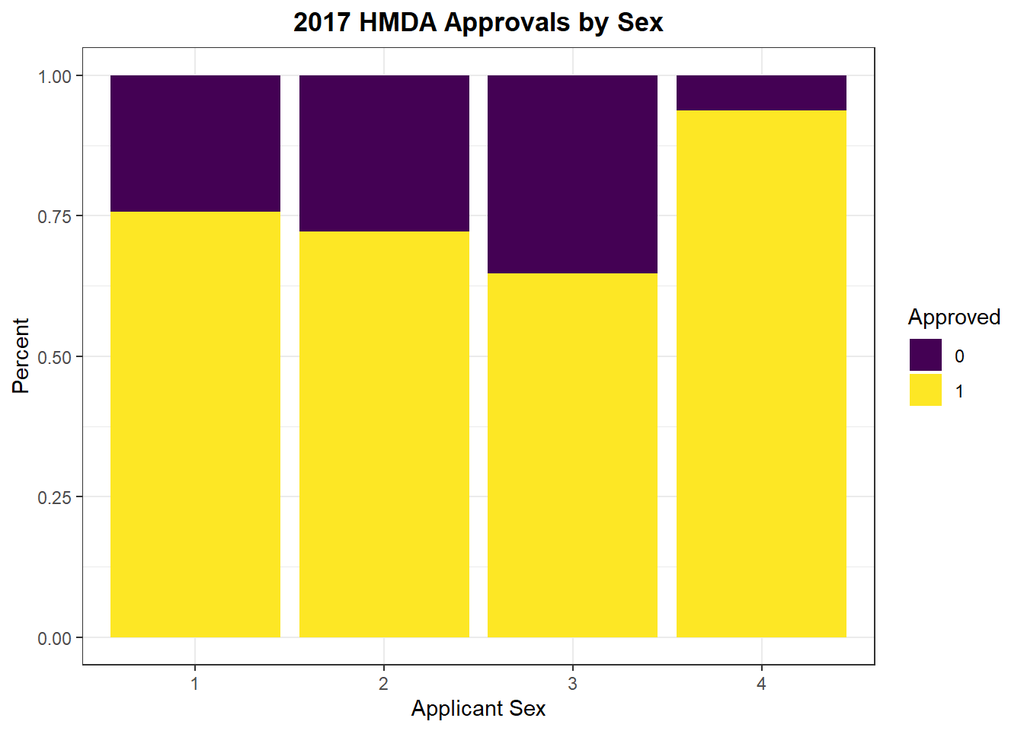

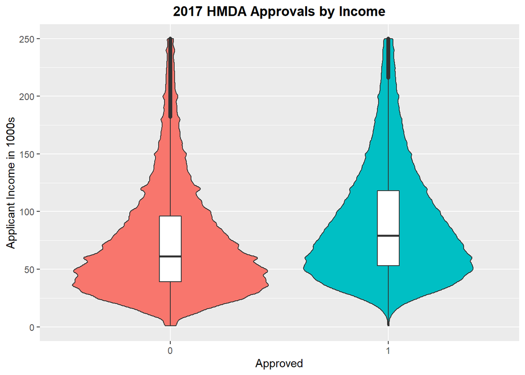

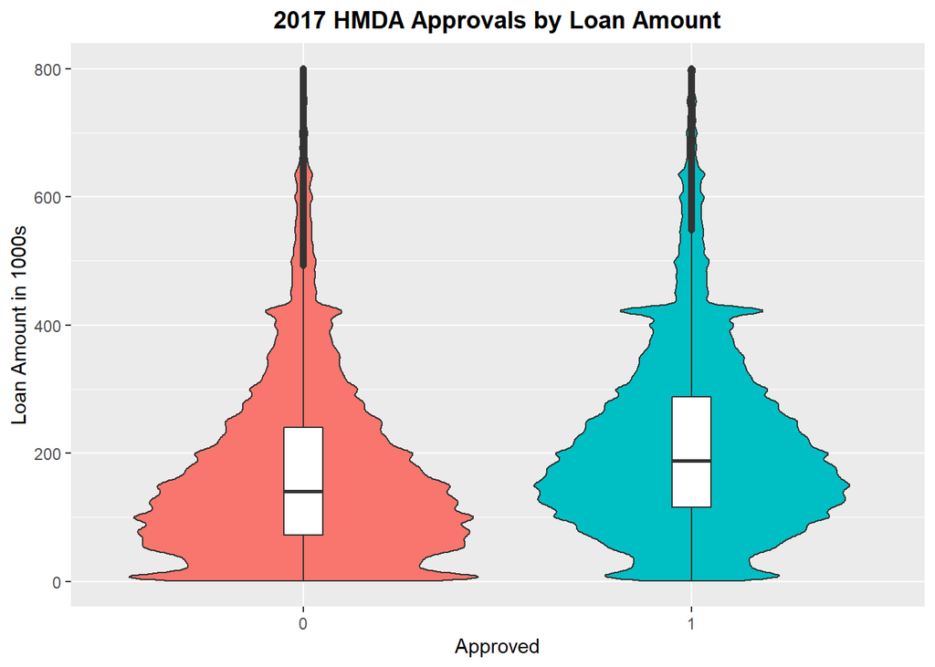